# P3 ANEMIA

Hemoglobina ajustada

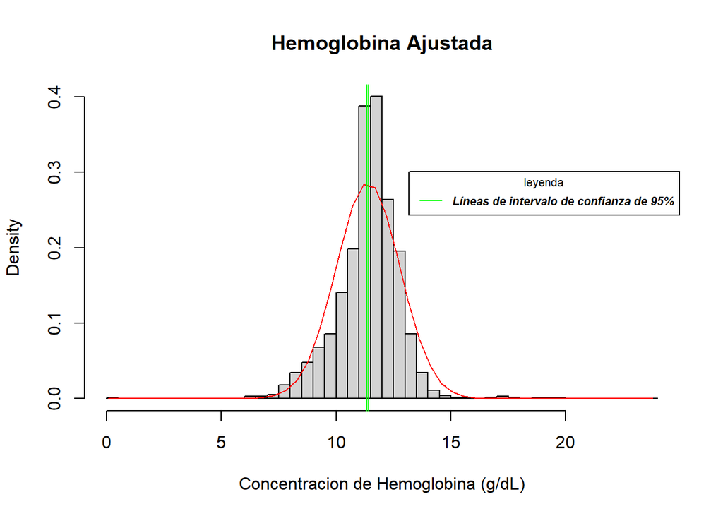

Peso

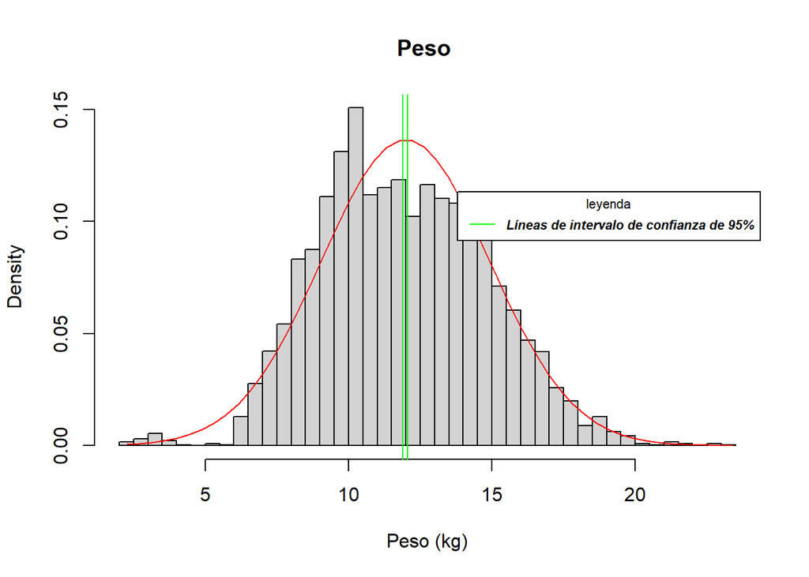

Talla

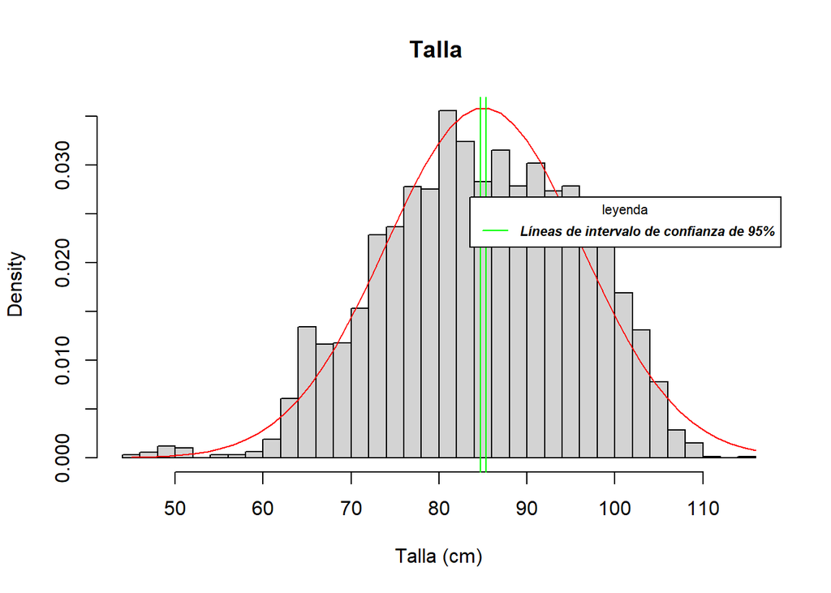

Normalizada de peso-edad (ZPE)

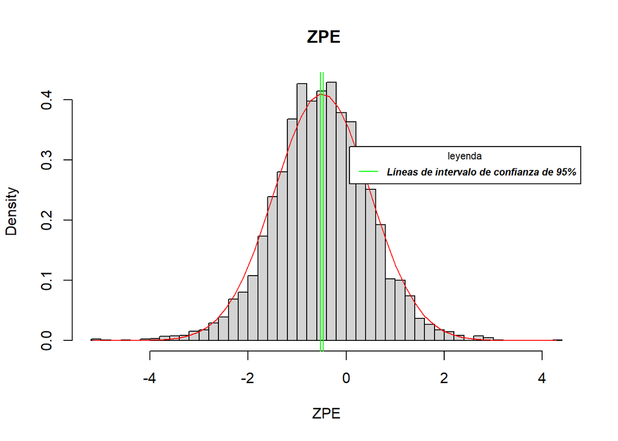

Normalizada de talla-edad (ZTE)

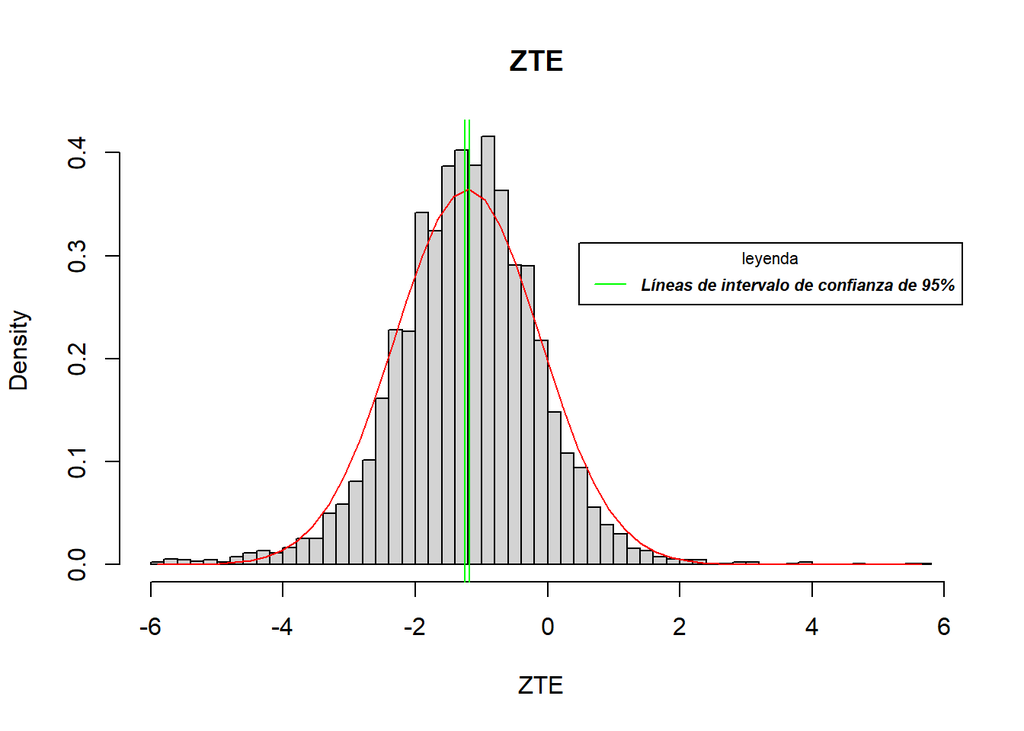

Índice de masa corporal (IMC)

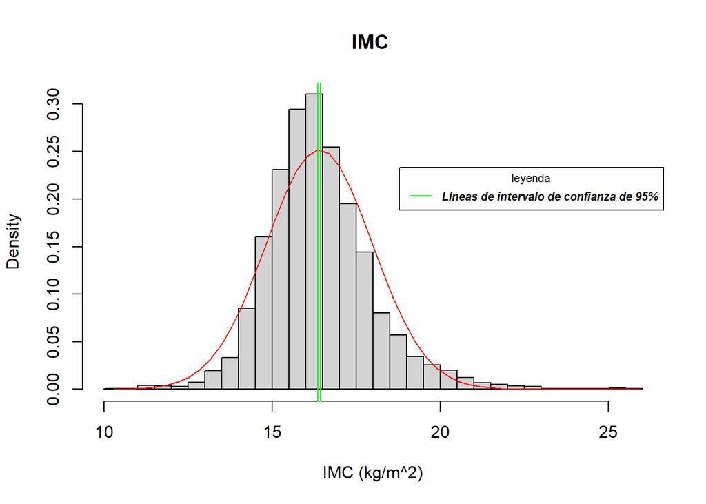

**Intervalos de confianza**

Las variables presentadas evidentemente se asemejan a una variable aleatoria continua con distribución normal. A continuación se mostrarán algunos parámetros.

- Nivel de confianza: 95%

- α=0.05

- Tamaño de la muestra: 4500

Se emplea este nivel de confianza por convención y para dar credibilidad a nuestros resultados.

**Desviación estándar y media de las variables:**

Abajo se ven las desviaciones estándar y medias de nuestras variables.

| Variable | Desviación estándar (σ) | Media (μ) |
| --- | --- | --- |
| Concentración de hemoglobina (g/dL) | 1.3929 | 11.387 |
| Peso (kg) | 2.9222 | 11.9803 |
| Talla (cm) | 11.1219 | 85.0515 |
| ZPE | 0.9724 | -0.4903 |
| ZTE | 1.0942 | -1.214 |
| IMC (kg/m^2) | 1.5847 | 16.4004 |

**Intervalos de confianza de las medias:**

Abajo se ven los intervalos de confianza de la media con un nivel de confianza de 95%. También se ven las medias dentro de nuestra muestra.

| Variable | Límite inferior | Límite superior | μ |
| --- | --- | --- | --- |
| Concentración de hemoglobina (g/dL) | 11.3463 | 11.4277 | 11.387 |
| Peso (kg) | 11.8949 | 12.0656 | 11.9803 |
| Talla (cm) | 84.7265 | 85.3764 | 85.0515 |
| ZPE | -0.5187 | -0.4619 | -0.4903 |
| ZTE | -1.246 | -1.1821 | -1.214 |
| IMC (kg/m^2) | 16.3541 | 16.4467 | 16.4004 |

**Pruebas de hipótesis:**

Para las pruebas de hipótesis, antes planteamos tres preguntas relevantes que podrían ser respondidas por estas pruebas:

- Pregunta 1: ¿Hay una mayor concentración de hemoglobina ajustada en la sangre de los niños y niñas que forman parte de algún programa de ayuda social?
- Pregunta 2: ¿Los indicadores de crecimiento (como la nutrición y la talla) están relacionados a la concentración de hemoglobina ajustada en la sangre?
- Pregunta 3: ¿La ubicación geográfica influye en la concentración de hemoglobina ajustada en la sangre?

**Pregunta 1**

¿Hay menor incidencia de anemia en los niños y niñas que forman parte de algún programa de ayuda social?

Debido a que hay dos programas sociales relevantes, se plantearon dos sub hipótesis:

**Hipótesis 1**

Variable analizada: Hemoglobina_Ajustada (Se comparan los datos de los niños afiliados y no afiliados a Qaliwarma).

Aquí se puede ver un breve resumen estadístico de la muestra que accede a Qaliwarma.

```
##    Min. 1st Qu.  Median    Mean 3rd Qu.    Max.
##   8.516  11.076  11.728  11.763  12.476  13.734
```

Acá se ve un resumen estadístico de la muestra que no accede a Qaliwarma.

```
##     Min.  1st Qu.   Median     Mean  3rd Qu.     Max.
##  0.07585 10.74995 11.50900 11.38079 12.14641 23.77983
```

Realizamos también gráficos de caja y bigotes de la concentración ajustada de hemoglobina en los afiliados y no afiliados a Qaliwarma:

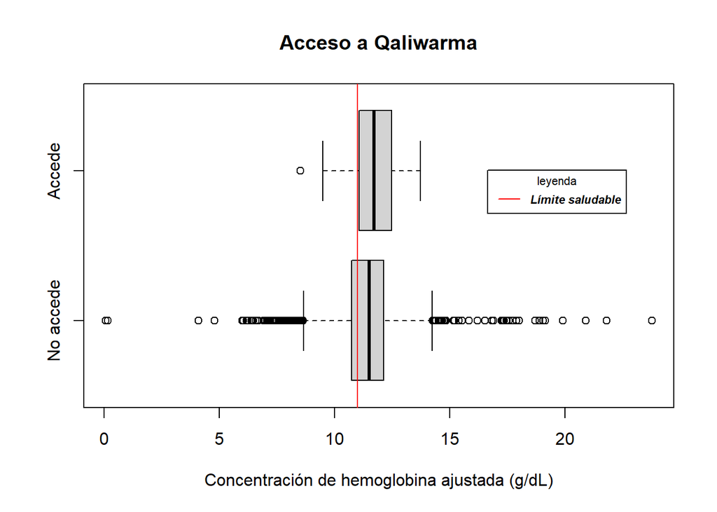

Parámetros de la hipótesis 1:

- H0: La diferencia de las medias de la concentración de hemoglobina en la sangre entre los niños afiliados y no afiliados a Qaliwarma es 0.
- H1: La media de la concentración de hemoglobina en la sangre de los niños afiliados a Qaliwarma es mayor que la media de la concentración de hemoglobina en la sangre de los niños no afiliados a este programa.

- Variable: Hemoglobina_Ajustada

- Prueba de hipótesis: Unilateral derecha

- Estimador puntual: Media

- Modelo: Prueba Z

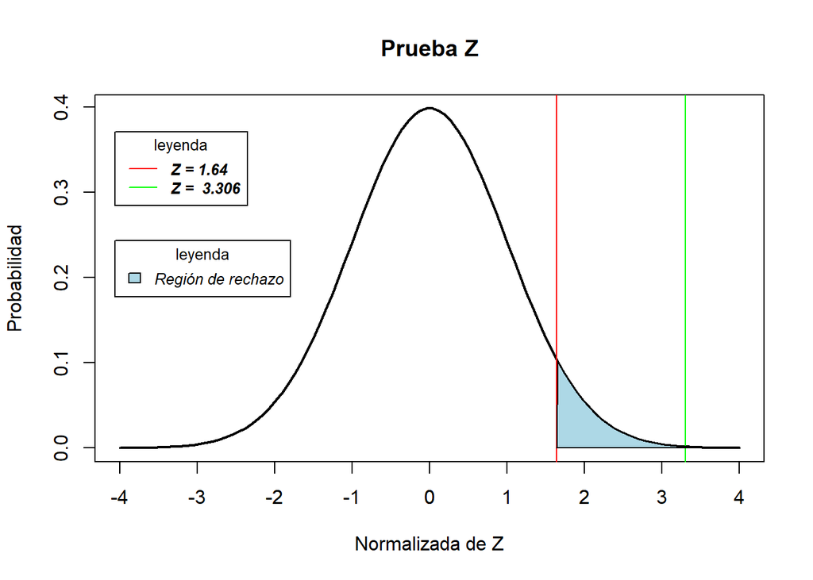

```
## [1] 0.0004731904
```

- Estadístico de prueba: 3.306
- Valor crítico: 1.64
- p-valor: 0.000473
- Prueba de hipótesis: Unilateral derecha

Observaciones:

- La zona de rechazo para la hipótesis nula sería z<sub>p</sub> ≥ 1.64
- z<sub>p</sub> = 3.306, cae en la zona de rechazo.
- p-valor = 0.000473, el cual es menor que la significancia (α=0.05)
- Se rechaza la hipótesis nula tras haber encontrado evidencia suficiente.

**Hipótesis 2**

Variable analizada: Hemoglobina_Ajustada

Aquí se puede ver un resumen estadístico de la muestra que accede a Juntos.

```
##     Min.  1st Qu.   Median     Mean  3rd Qu.     Max.
##  0.07585 10.66490 11.53844 11.35682 12.17103 19.14407
```

Acá se ve un resumen estadístico de la muestra que no accede a Juntos.

```
##    Min. 1st Qu.  Median    Mean 3rd Qu.    Max.
##  0.1759 10.7935 11.4942 11.3975 12.1282 23.7798
```

Realizamos gráficos de caja y bigotes de la concentración ajustada de hemoglobina en los afiliados y no afiliados a Juntos.

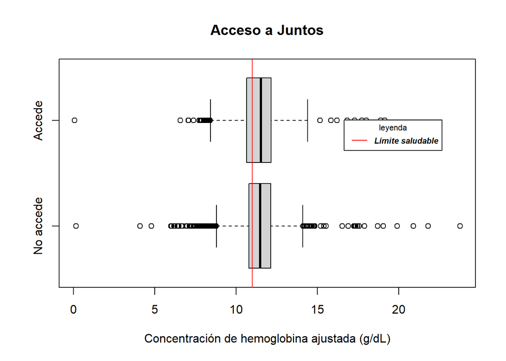

Parámetros de la hipótesis 2:

- H0: La diferencia de las medias de la concentración de hemoglobina en la sangre entre los niños afiliados y no afiliados a Juntos es 0.
- H1: La media de la concentración de hemoglobina en la sangre de los niños afiliados a Juntos es menor que la de los niños no afiliados a este programa.

- Variable: Hemoglobina_Ajustada

- Prueba de hipótesis: Unilateral izquierda

- Estimador puntual: Media

- Modelo: Prueba Z

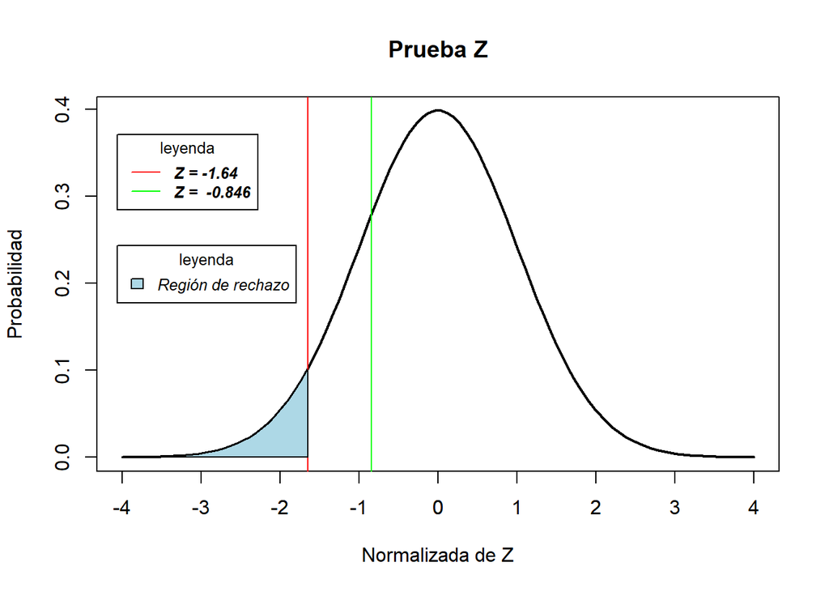

```
## [1] 0.1987764
```

- Estadístico de prueba: -0.846
- Valor crítico: -1.64
- p-valor: 0.1987764
- Prueba de hipótesis: Unilateral izquierda

Observaciones:

- La zona de rechazo para la hipótesis nula sería z<sub>p</sub> ≤ -1.64
- z<sub>p</sub> = -0.846, no cae en la zona de rechazo.
- p-valor = 0.1987764, el cual es mayor que la significancia (α=0.05)
- No hay suficiente evidencia para rechazar la hipótesis nula.

**Pregunta 2**

¿Los indicadores de crecimiento (I.M.C y normalizada de talla-edad) están relacionados a la concentración de hemoglobina ajustada?

- Hipótesis 1: Hay diferencias entre el IMC de los niños anémicos y no anémicos.
- Hipótesis 2: Los niños anémicos en promedio presentan menores estaturas para su edad que los niños no anémicos.

**Hipótesis 1**

Variable analizada: IMC

Resumen del IMC en niños anémicos:

```
##    Min. 1st Qu.  Median    Mean 3rd Qu.    Max.
##   10.76   15.41   16.29   16.46   17.31   24.85
```

Resumen del IMC en niños no anémicos:

```
##    Min. 1st Qu.  Median    Mean 3rd Qu.    Max.
##   10.29   15.41   16.21   16.38   17.17   25.95
```

Realizamos gráficos de caja y bigotes del IMC en niños anémicos y no anémicos:

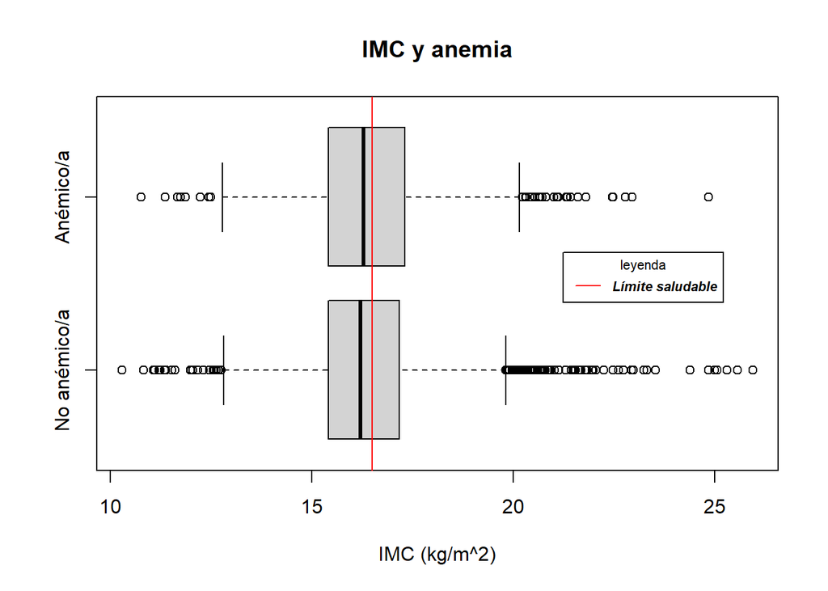

Parámetros de la hipótesis 1:

- H0: La diferencia de las medias del IMC entre los niños anémicos y no anémicos es 0.
- H1: La diferencia de las medias del IMC entre los niños anémicos y no anémicos no es 0.

- Variable: IMC

- Prueba de hipótesis: Bilateral

- Estimador puntual: Media

- Modelo: Prueba Z

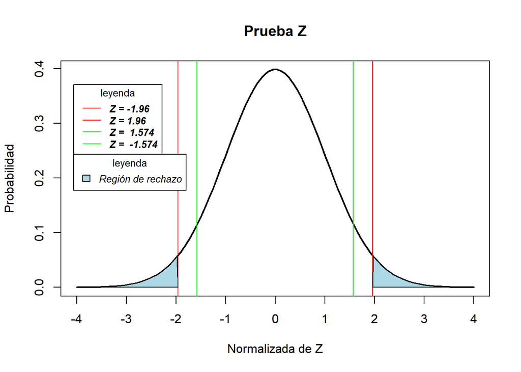

```
## [1] 0.1154874
```

- Estadístico de prueba: ±1.574
- Valor crítico: ±1.96
- p-valor: 0.1154874
- Prueba de hipótesis: Bilateral

Observaciones:

- La zona de rechazo para la hipótesis nula sería z<sub>p</sub> ≥ 1.96 (ó z<sub>p</sub> ≤ -1.96)
- z<sub>p</sub> = ±1.574, no cae en la zona de rechazo.
- p-valor = 0.1154874, el cual es mayor que la significancia (α=0.05)
- No hay suficiente evidencia para rechazar la hipótesis nula.

**Hipótesis 2**

Variable analizada: ZTE

Resumen de talla-edad en niños anémicos:

```
##    Min. 1st Qu.  Median    Mean 3rd Qu.    Max.
##  -5.710  -1.980  -1.280  -1.311  -0.630   3.890
```

Resumen de talla-edad en niños no anémicos:

```
##    Min. 1st Qu.  Median    Mean 3rd Qu.    Max.
##  -5.910  -1.810  -1.140  -1.172  -0.500   5.650
```

Realizamos gráficos de caja y bigotes de la normalizada de la talla-edad en los niños anémicos y no anémicos.

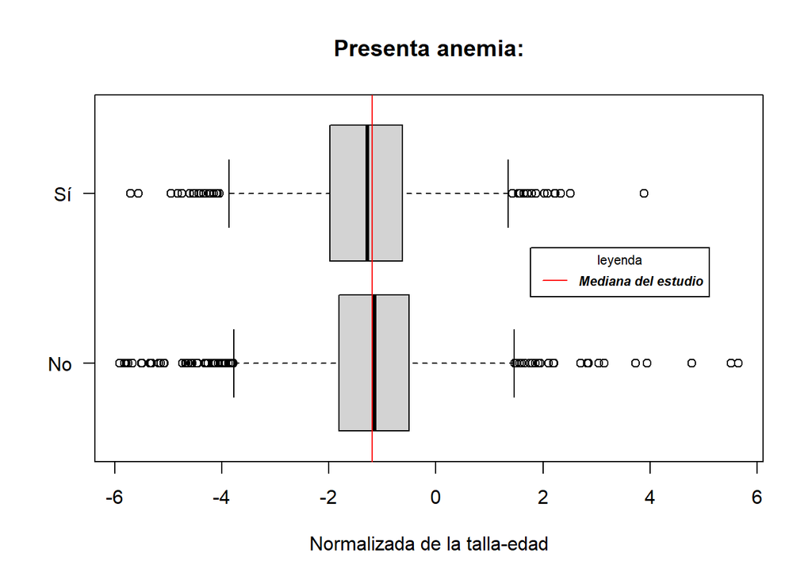

Parámetros de la hipótesis 2:

- H0: La diferencia de las medias de la normalizada de la talla-edad entre los niños anémicos y no anémicos es 0.
- H1: La media de la normalizada de la talla-edad es menor en los niños anémicos que en los no anémicos.

- Variable: ZTE

- Prueba de hipótesis: Unilateral izquierda

- Estimador puntual: Media

- Modelo: Prueba Z

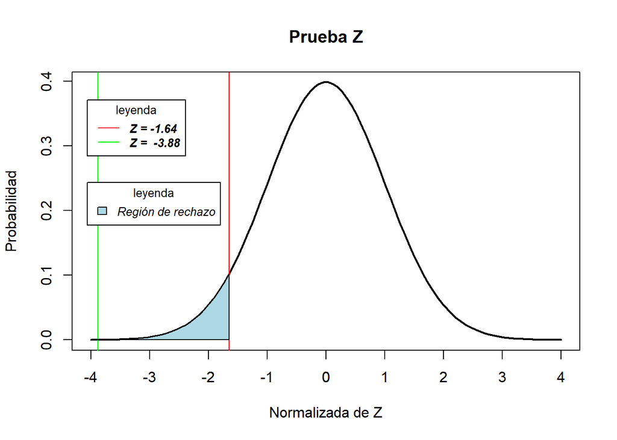

```
## [1] 5.222823e-05
```

- Estadístico de prueba: -3.88
- Valor crítico: -1.64
- p-valor: 5.222823e-05
- Prueba de hipótesis: Unilateral izquierda

Observaciones:

- La zona de rechazo para la hipótesis nula sería z<sub>p</sub> ≤ -1.645452
- z<sub>p</sub> = -3.88, cae en la zona de rechazo
- p-valor = 5.222823e-05, el cual es menor que la significancia (α=0.05)
- Hay suficiente evidencia para rechazar la hipótesis nula.

**Pregunta 3**

¿La ubicación geográfica influye en la incidencia de anemia?

**Hipótesis 1**

Variable analizada: Hemoglobina_Ajustada

Resumen de concentración de hemoglobina ajustada en niños sobre los 2930 msnm:

```
##     Min.  1st Qu.   Median     Mean  3rd Qu.     Max.
##  0.07585 10.22952 11.27937 11.10403 12.02952 20.90547
```

Resumen de concentración de hemoglobina ajustada en niños bajo los 2930 msnm:

```
##    Min. 1st Qu.  Median    Mean 3rd Qu.    Max.
##   7.513  11.111  11.711  11.705  12.287  23.780
```

Realizamos gráficos de caja y bigotes de la concentración ajustada de hemoglobina en niños por encima y por debajo de los 2930 msnm.

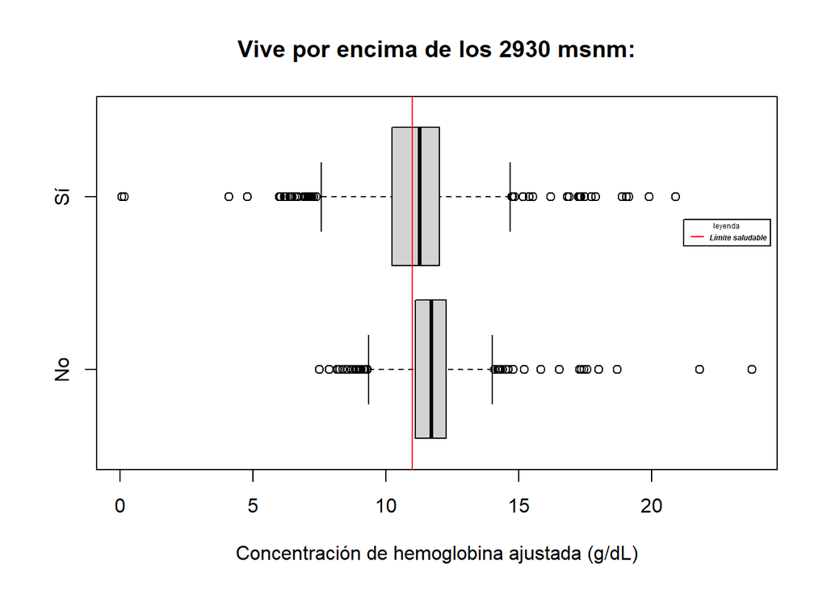

Parámetros de la hipótesis 1:

- H0: La diferencia de las medias de la concentración de hemoglobina ajustada entre los niños que viven por encima y por debajo de los 2930 msnm es 0.
- H1: La media de la concentración de hemoglobina ajustada es menor en los niños que viven por encima de los 2930 msnm que en quienes viven bajo esta altura.

- Variable: Hemoglobina_Ajustada

- Prueba de hipótesis: Unilateral izquierda

- Estimador puntual: Media

- Modelo: Prueba Z

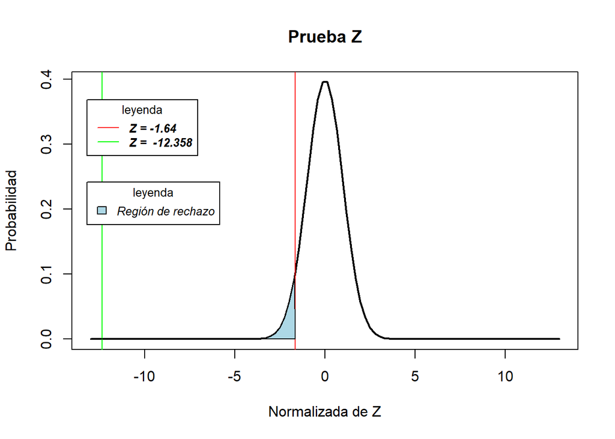

```
## [1] 2.204962e-35
```

- Estadístico de prueba: -12.358
- Valor crítico: -1.64
- p-valor: 2.204962e-35
- Prueba de hipótesis: Unilateral izquierda

Observaciones:

- La zona de rechazo para la hipótesis nula sería z<sub>p</sub> ≤ -1.64
- z<sub>p</sub> = -12.358, cae en la zona de rechazo.
- p-valor = 2.204962e-35, el cual es menor que la significancia (α=0.05)
- Hay suficiente evidencia para rechazar la hipótesis nula.

**Hipótesis 2**

Variable analizada: Hemoglobina_Ajustada

Resumen de la concentración de hemoglobina ajustada de los niños que viven en Cotabambas:

```
##    Min. 1st Qu.  Median    Mean 3rd Qu.    Max.
##   4.794   9.776  11.150  10.959  12.082  17.740
```

Resumen de la concentración de hemoglobina ajustada de los niños que viven en otras partes de Apurímac:

```
##     Min.  1st Qu.   Median     Mean  3rd Qu.     Max.
##  0.07585 10.97983 11.55670 11.51241 12.16892 23.77983
```

Realizamos gráficos de caja y bigotes de la concentración ajustada de hemoglobina en niños que viven y no viven en Cotabambas.

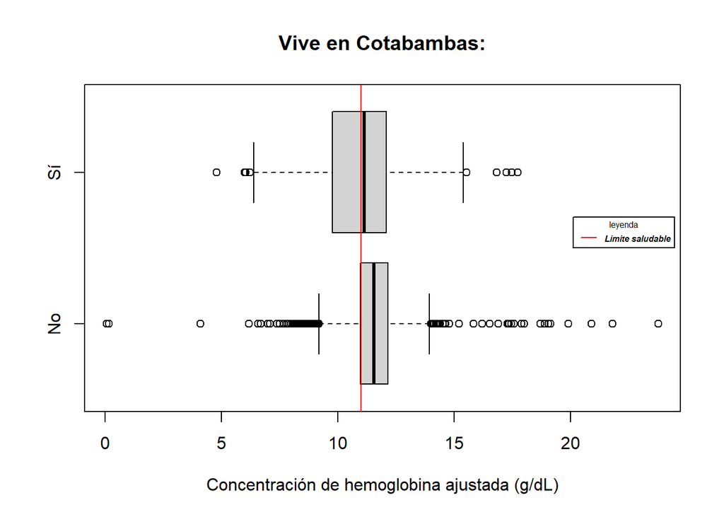

Parámetros de la hipótesis 2:

- H0: La diferencia de las medias de la concentración de hemoglobina ajustada entre los niños que viven y no viven en Cotabambas es 0.
- H1: La media de la concentración de hemoglobina ajustada es menor en los niños que viven en Cotabambas que en quienes viven en otras provincias de Apurímac.

- Variable: Hemoglobina_Ajustada

- Prueba de hipótesis: Unilateral izquierda

- Estimador puntual: Media

- Modelo: Prueba Z

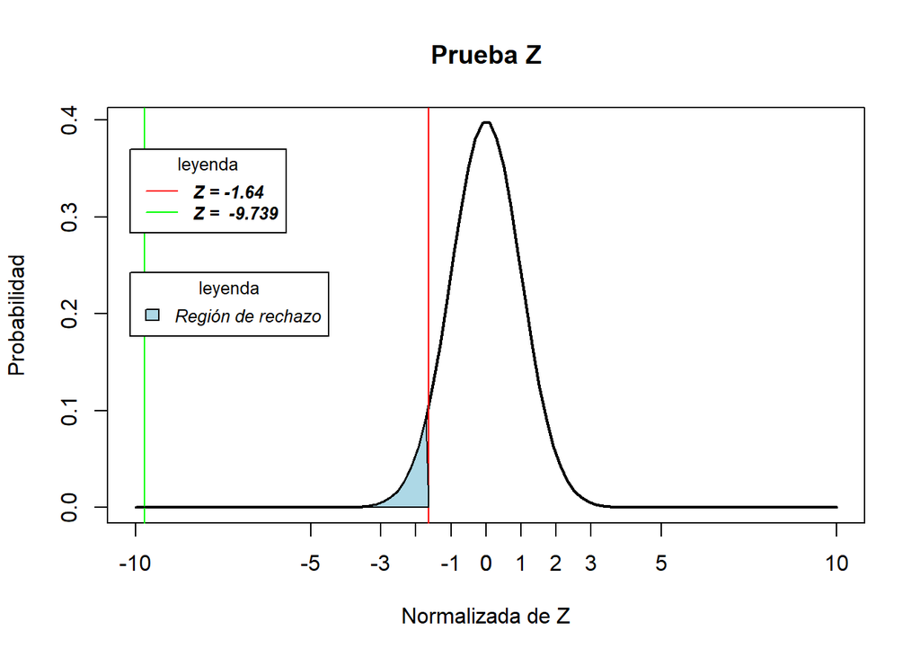

```
## [1] 1.027836e-22
```

- Estadístico de prueba: -9.7391
- Valor crítico: -1.64
- p-valor: 1.027836e-22
- Prueba de hipótesis: Unilateral izquierda

Observaciones:

- La zona de rechazo para la hipótesis nula sería z<sub>p</sub> ≤ -1.64
- z<sub>p</sub> = -9.7391, cae en la zona de rechazo.
- p-valor = 1.027836e-22, el cual es menor que la significancia (α=0.05).
- Hay suficiente evidencia para rechazar la hipótesis nula.

**Regresiones y predicciones**

**Regresión 1:**

Para nuestro primer modelo empleamos el método de mínimos cuadrados para hallar una regresión entre la concentración de la hemoglobina ajustada y la normalizada de la talla-edad.

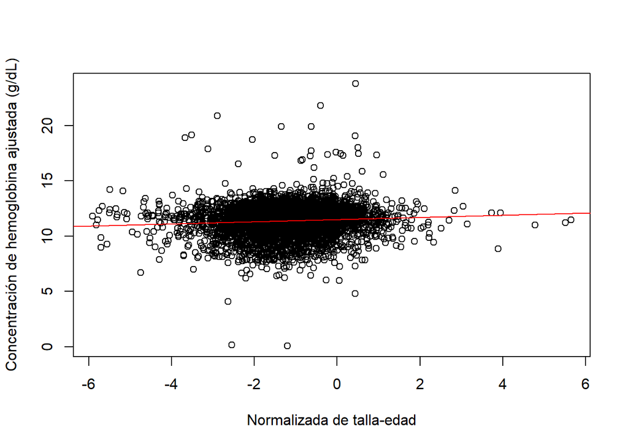

Abajo se ve un breve resumen de los parámetros relacionados al modelo de regresión.

```
##
## Call:
## lm(formula = ANEMIA$Hemoglobina_Ajustada ~ ANEMIA$ZTE)
##
## Residuals:
##      Min       1Q   Median       3Q      Max
## -11.3125  -0.6288   0.1001   0.7741  12.2326
##
## Coefficients:
##             Estimate Std. Error t value Pr(>|t|)
## (Intercept) 11.50388    0.03093 371.936  < 2e-16 ***
## ANEMIA$ZTE   0.09629    0.01893   5.088 3.77e-07 ***
## ---
## Signif. codes:  0 '***' 0.001 '**' 0.01 '*' 0.05 '.' 0.1 ' ' 1
##
## Residual standard error: 1.389 on 4498 degrees of freedom
## Multiple R-squared:  0.005722,   Adjusted R-squared:  0.005501
## F-statistic: 25.88 on 1 and 4498 DF,  p-value: 3.773e-07
```

La distribución de los residuales sugiere que es apropiado emplear un modelo lineal.

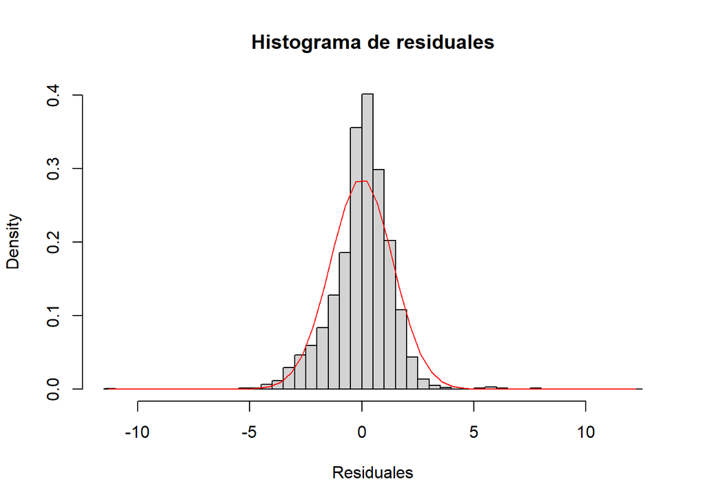

```
## [1] "Media de los residuos: 2.61069715228817e-16"
```

**Observaciones**

- Con respecto a residuales:
  - Distribución cercana a una normal y con media aproximadamente igual a 0.
  - Hay valores fuera de la curva de la normal.
- Respecto a los coeficientes:
  - Intercepto: para una significancia de 0.05, p = 2e-16, por lo que la hipótesis nula (H0) se rechaza y el valor de b≠0.
  - Pendiente: para una significancia de 0.05, p = 3.77e-07, por lo que la hipótesis nula (H0) se rechaza y el valor de a≠0.
- Con respecto a r<sup>2</sup> ajustado:
  - La variación de la variable de concentración de la hemoglobina ajustada se explica solamente en un 0.5501% a través de la variación de la variable normalizada de talla-edad.
  - A partir de esto, se sugiere que la normalizada de talla-edad no es muy útil para explicar la variación de la concentración de la hemoglobina ajustada.
  - Es probable que existan otras variables que influyan en la variación de la concentración de la hemoglobina ajustada.
- Con respecto al p−value:
  - p−value (3.773e-07) es menor que la significancia (α=0.05).
  - Se rechaza la hipótesis nula H0.
  - Se sugiere que el modelo explica la relación entre las variables.

**Función de correlación**

Dado que se rechace la hipótesis nula y la relación entre las variables sea significativa, la fórmula para determinar la concentración de hemoglobina ajustada en función de la normalizada de talla-edad sería:

$$Hemoglobina_{(concentración)} = 0.09629(ZTE) + 11.50388$$

El intercepto muestra la concentración de hemoglobina esperada en un niño con una normalizada de talla-edad de 0. La pendiente muestra el aumento equivalente de la concentración de hemoglobina en la sangre cuando se aumenta la normalizada de talla-edad por una unidad en este modelo.

**Gráficas de diagnóstico**

A partir de estas gráficas se pueden hacer algunas observaciones respecto a la relevancia del modelo linea.

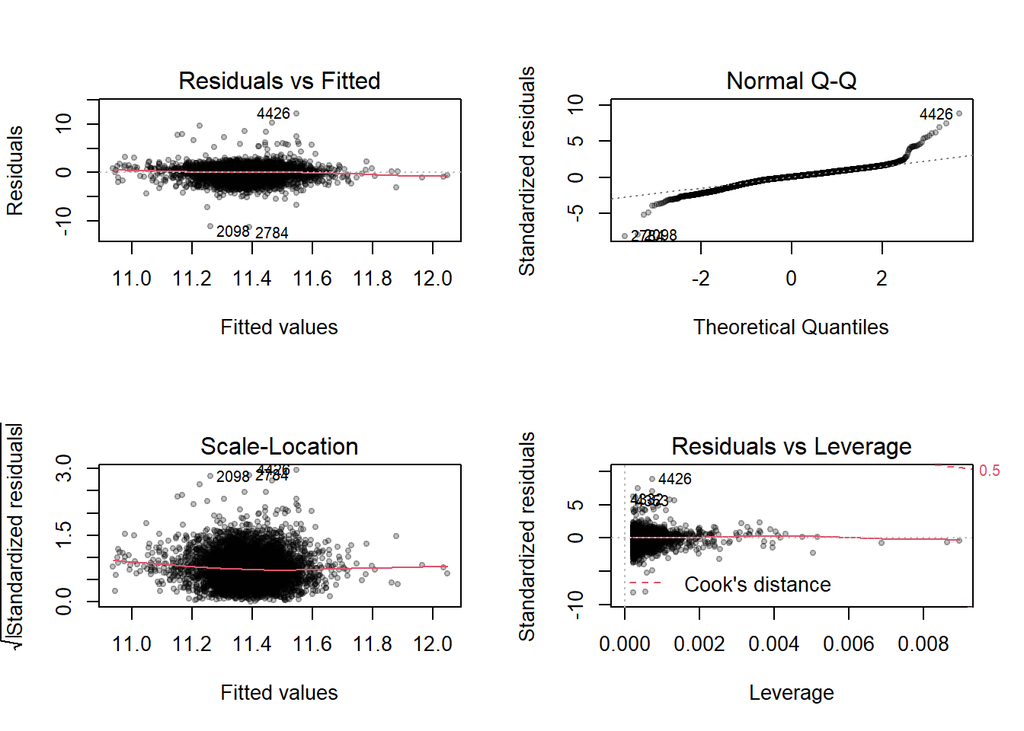

De acuerdo a las gráficas de diagnóstico de la línea de ajuste, se tienen las siguientes observaciones:

- Con respecto a la gráfica de “Residuos vs. Valores ajustados”:
  - Existen 3 valores atípicos.
  - Se pueden observar residuos positivos y negativos distribuidos alrededor de la línea roja
  - Los residuos son heterocedásticos, se puede ver que su varianza es variada y es mayor en los valores ajustados centrales.
- Con respecto a la gráfica de la “Normal Q-Q”:
  - Tenemos valores atípicos que afectan en cierta medida la forma de distribución normal de los residuos.
  - Parece ser que nuestros datos tienen más valores extremos de los que se esperaría en una verdadera distribución normal.
- Con respecto a la gráfica “Scale-Location”:
  - Los residuos estandarizados NO están distribuidos uniformemente alrededor de la recta roja pero esta parece ser plana. A partir de la gráfica se refuerza la condición de heterocedasticidad del modelo, ya que se ve que la varianza es mayor en los valores ajustados centrales.
- Con respecto a la gráfica “Residual vs. Leverage”:
  - Se puede observar que no existen puntos que produzcan efecto palanca alguno, por lo que no hay valores que afecten la tendencia.

**Uso del modelo para hacer predicciones**

Usamos ZTE = 4.68 porque no tenemos ninguna muestra con ese valor.

$$Hemoglobina_{(concentración)} = 0.09629(ZTE) + 11.50388$$

$$Hemoglobina_{(concentración)} = 0.09629(4.68) + 11.50388$$

$$Hemoglobina_{(concentración)} = 11.95444 g/dL$$

Esto podemos compararlo con un individuo de otra base de datos de Apurímac en el 2019. Este tiene una concentración de hemoglobina de 13.6 g/dL y vive a una altura de 3165 msnm, por lo que su hemoglobina ajustada sería de 11.5602 g/dL. Esto representa un error de 3.41%

Aunque todas las pruebas de hipótesis sugieren que el modelo de regresión es valido, al analizar el r<sup>2</sup> se evidencia que la normalizada de talla-edad influencia la variación de la concentración de hemoglobina a un grado poco significativo. Por este motivo, se puede concluir que nuestro modelo posiblemente describe a grandes rasgos el comportamiento de estas dos variables, pero no es muy útil para más que esto.

**Regresión 2:**

Otro modelo que consideramos también emplea el método de mínimos cuadrados, pero en este caso buscamos hallar una regresión entre la concentración de la hemoglobina ajustada y la normalizada de peso-edad.

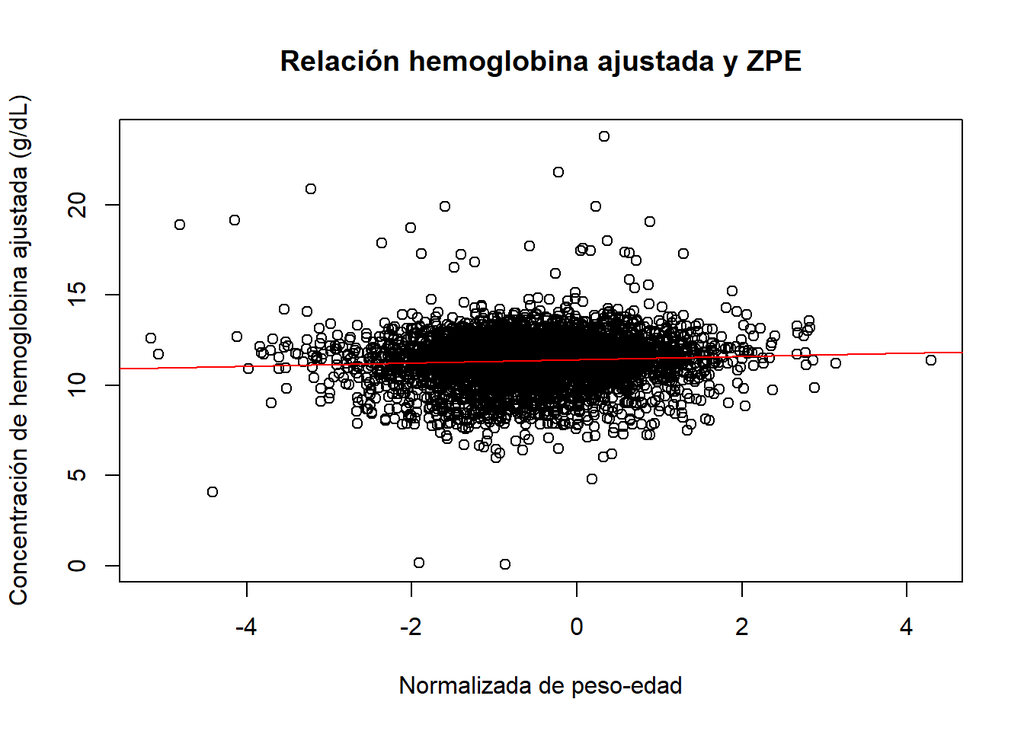

Abajo se ve un breve resumen de los parámetros relacionados al modelo de regresión.

```
##
## Call:
## lm(formula = ANEMIA$Hemoglobina_Ajustada ~ ANEMIA$ZPE)
##
## Residuals:
##      Min       1Q   Median       3Q      Max
## -11.2761  -0.6124   0.1053   0.7603  12.3172
##
## Coefficients:
##             Estimate Std. Error t value Pr(>|t|)
## (Intercept) 11.43221    0.02321 492.593  < 2e-16 ***
## ANEMIA$ZPE   0.09225    0.02131   4.328 1.54e-05 ***
## ---
## Signif. codes:  0 '***' 0.001 '**' 0.01 '*' 0.05 '.' 0.1 ' ' 1
##
## Residual standard error: 1.39 on 4498 degrees of freedom
## Multiple R-squared:  0.004148,   Adjusted R-squared:  0.003926
## F-statistic: 18.73 on 1 and 4498 DF,  p-value: 1.535e-05
```

La distribución de los residuales sugiere que es apropiado emplear un modelo lineal.

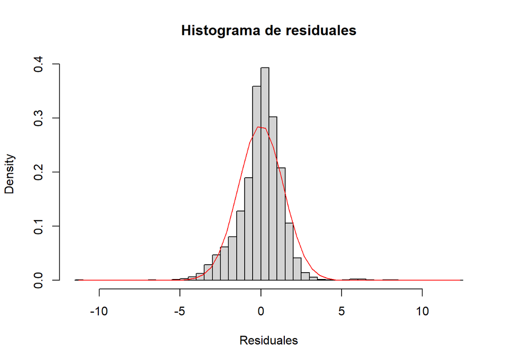

```
## [1] "Media de los residuos: 1.52017094899747e-16"
```

**Observaciones**

- Con respecto a residuales:
  - Distribución cercana a una normal y con media aproximadamente igual a 0.
  - Hay valores fuera de la curva de la normal.
- Respecto a los coeficientes:
  - Intercepto: para una significancia de 0.05, p = 2e-16, por lo que la hipótesis nula (H0) se rechaza y el valor de b≠0.
  - Pendiente: para una significancia de 0.05, p = 1.54e-05, por lo que la hipótesis nula (H0) se rechaza y el valor de a≠0.
- Con respecto a r<sup>2</sup> ajustado:
  - La variación de la variable de concentración de la hemoglobina ajustada se explica solamente en un 0.3926 % a través de la variación de la normalizada de peso-edad.
  - A partir de esto, se sugiere que la normalizada de peso-edad no es muy útil para explicar la variación de la concentración de la hemoglobina ajustada.
  - Se sugiere que existen otras variables que influyen en la variación de la concentración de la hemoglobina ajustada.
- Con respecto al p−value:
  - p−value (1.535e-05) es menor que la significancia (α=0.05).
  - Se rechaza la hipótesis nula H0.
  - Se sugiere que el modelo explica la relación entre las variables.

**Gráficas de diagnóstico**

A partir de estas gráficas se pueden hacer algunas observaciones respecto a la relevancia del modelo linea.

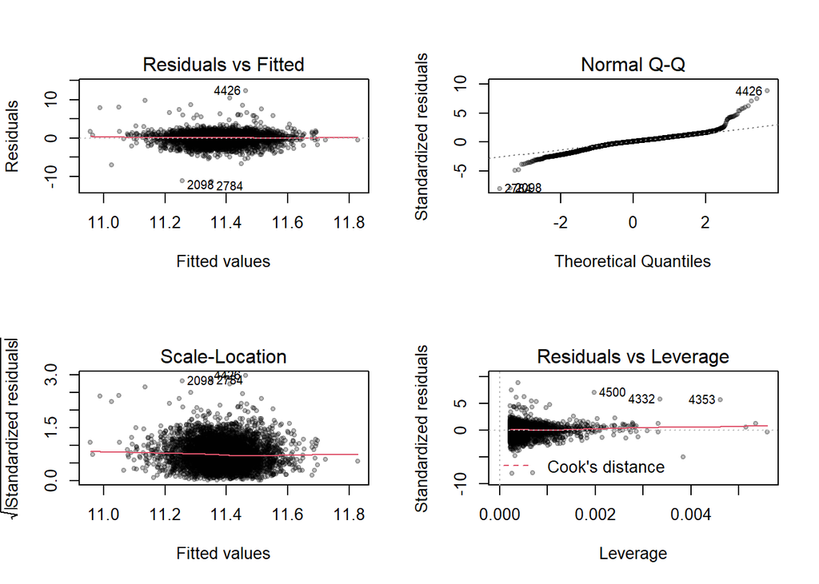

De acuerdo a las gráficas de diagnóstico de la línea de ajuste, se tienen las siguientes observaciones:

- Con respecto a la gráfica de “Residuos vs. Valores ajustados”:
  - Existen 3 valores atípicos.
  - Se pueden observar residuos positivos y negativos distribuidos alrededor de la línea roja
  - Los residuos son heterocedásticos, pero esto parece ser debido a la ausencia de observaciones para una mayor variedad de alturas.
- Con respecto a la gráfica de la “Normal Q-Q”:
  - Tenemos valores atípicos que afectan en cierta medida la forma de distribución normal de los residuos.
  - Parece ser que nuestros datos tienen más valores extremos de los que se esperaría en una verdadera distribución normal.
- Con respecto a la gráfica “Scale-Location”:
  - Los residuos estandarizados no están distribuidos uniformemente alrededor de la recta roja pero esta parece ser plana. A partir de la gráfica se refuerza la condición de heterocedasticidad del modelo, que no obstante parece ser circunstancial y causada por el método de recopilación de datos.
- Con respecto a la gráfica “Residual vs. Leverage”:
  - Se puede observar que no existen puntos que produzcan efecto palanca alguno, por lo que no hay valores que afecten la tendencia.

**Uso del modelo para hacer predicciones**

Usamos ZPE = 3.29 porque no tenemos ninguna muestra con ese valor.

$$Hemoglobina_{(concentración)} = 0.09225(ZPE) + 11.43221$$

$$Hemoglobina_{(concentración)} = 0.09225(3.29) + 11.43221$$

$$Hemoglobina_{(concentración)} = 11.73571 g/dL$$

Esto podemos compararlo con un individuo de otra base de datos de Apurímac en el 2019. Este sí tiene un ZPE de ese valor. También tiene una concentración de hemoglobina de 13.3 g/dL y vive a 2378 msnm, por lo que su hemoglobina ajustada sería de 12.21058 g/dL.. Esto representa un error de 4.0464%.

Aunque todas las pruebas de hipótesis sugieren que el modelo de regresión es valido, al analizar el r<sup>2</sup> se evidencia que la normalizada de peso-edad influencia la variación de la concentración de hemoglobina a un grado poco significativo. Por este motivo, se puede concluir que nuestro modelo posiblemente describe a grandes rasgos el comportamiento de estas dos variables, pero no es muy útil para más que esto.

**Regresión 3:**

Otro modelo que consideramos también emplea el método de mínimos cuadrados, pero en este caso buscamos hallar una regresión entre la concentración de la hemoglobina ajustada y la altura sobre el nivel del mar.

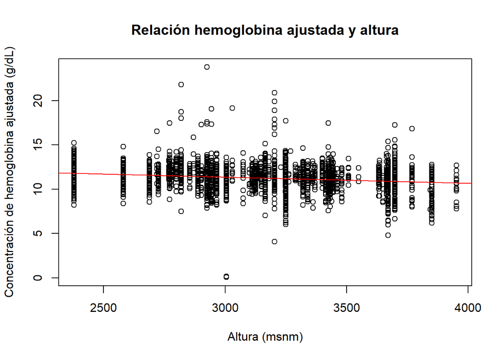

Abajo se ve un breve resumen de los parámetros relacionados al modelo de regresión.

```
##
## Call:
## lm(formula = ANEMIA$Hemoglobina_Ajustada ~ ANEMIA$AlturaREN)
##
## Residuals:
##      Min       1Q   Median       3Q      Max
## -11.3004  -0.7004   0.0890   0.7710  12.3480
##
## Coefficients:
##                    Estimate Std. Error t value Pr(>|t|)
## (Intercept)       1.347e+01  1.359e-01   99.06   <2e-16 ***
## ANEMIA$AlturaREN -6.950e-04  4.495e-05  -15.46   <2e-16 ***
## ---
## Signif. codes:  0 '***' 0.001 '**' 0.01 '*' 0.05 '.' 0.1 ' ' 1
##
## Residual standard error: 1.357 on 4498 degrees of freedom
## Multiple R-squared:  0.05047,    Adjusted R-squared:  0.05026
## F-statistic: 239.1 on 1 and 4498 DF,  p-value: < 2.2e-16
```

La distribución de los residuales sugiere que es apropiado emplear un modelo lineal.

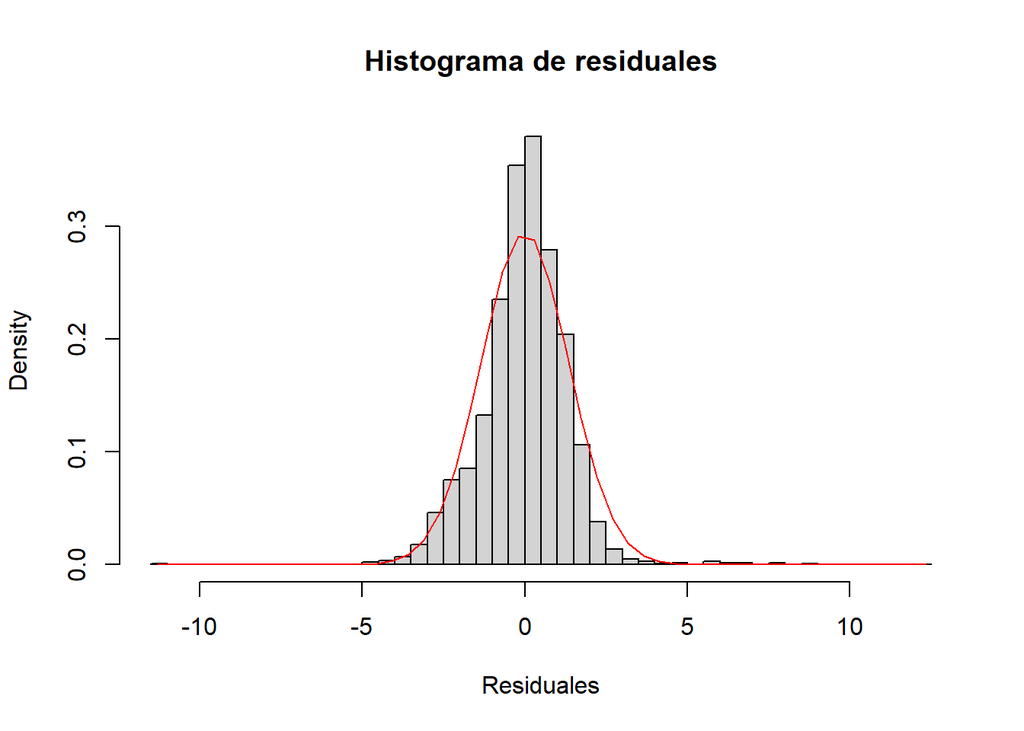

```
## [1] "Media de los residuos: 3.52226735432658e-16"
```

**Observaciones**

- Con respecto a residuales:
  - Distribución cercana a una normal y con media aproximadamente igual a 0.
  - Hay valores fuera de la curva de la normal.
- Respecto a los coeficientes:
  - Intercepto: para una significancia de 0.05, p = 2e-16, por lo que la hipótesis nula (H0) se rechaza y el valor de b≠0.
  - Pendiente: para una significancia de 0.05, p = 2e-16, por lo que la hipótesis nula (H0) se rechaza y el valor de a≠0.
- Con respecto a r<sup>2</sup> ajustado:
  - La variación de la variable de concentración de la hemoglobina ajustada se explica solamente en un 5.026 % a través de la variación de la altura sobre el nivel del mar.
  - A partir de esto, se sugiere que la altura sobre el nivel del mar no es muy útil para explicar la variación de la concentración de la hemoglobina ajustada.
  - Se sugiere que existen otras variables que influyen en la variación de la concentración de la hemoglobina ajustada.
- Con respecto al p−value:
  - p−value (2.2e-16) es menor que la significancia (α=0.05).
  - Se rechaza la hipótesis nula H0.
  - Se sugiere que el modelo explica la relación entre las variables.

**Función de correlación**

Dado que se rechace la hipótesis nula y la relación entre las variables sea significativa, la fórmula para determinar la concentración de hemoglobina ajustada en función de la altura sobre el nivel del mar sería:

$$Hemoglobina_{(concentración)} = -0.000695(Altura) + 13.47$$

El intercepto muestra la concentración de hemoglobina esperada en un niño que vive al nivel del mar. La pendiente muestra el aumento equivalente de la concentración de hemoglobina en la sangre cuando se aumenta la altura sobre el nivel del mar por un metro.

**Gráficas de diagnóstico**

A partir de estas gráficas se pueden hacer algunas observaciones respecto a la relevancia del modelo linea.

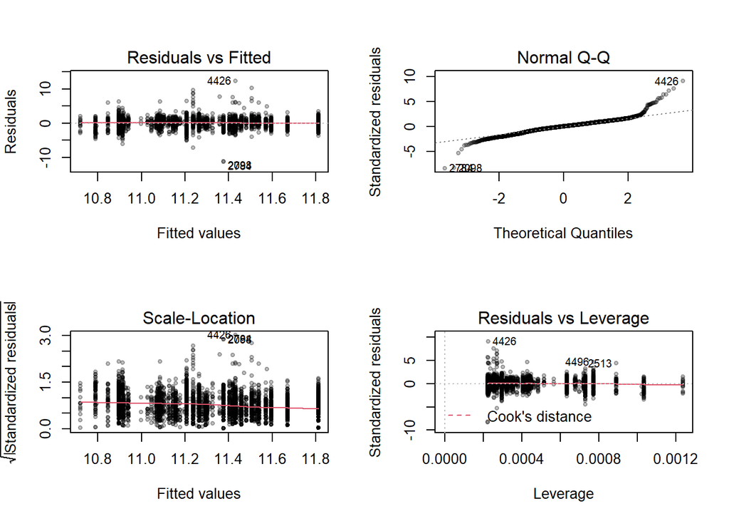

De acuerdo a las gráficas de diagnóstico de la línea de ajuste, se tienen las siguientes observaciones:

- Con respecto a la gráfica de “Residuos vs. Valores ajustados”:
  - Existen 3 valores atípicos.
  - Se pueden observar residuos positivos y negativos distribuidos alrededor de la línea roja
  - Los residuos son heterocedásticos, pero esto parece ser debido a la ausencia de observaciones para una mayor variedad de alturas.
- Con respecto a la gráfica de la “Normal Q-Q”:
  - Tenemos valores atípicos que afectan en cierta medida la forma de distribución normal de los residuos.
  - Parece ser que nuestros datos tienen más valores extremos de los que se esperaría en una verdadera distribución normal.
- Con respecto a la gráfica “Scale-Location”:
  - Los residuos estandarizados no están distribuidos uniformemente alrededor de la recta roja pero esta parece ser plana. A partir de la gráfica se refuerza la condición de heterocedasticidad del modelo, que no obstante parece ser circunstancial y causada por el método de recopilación de datos.
- Con respecto a la gráfica “Residual vs. Leverage”:
  - Se puede observar que no existen puntos que produzcan efecto palanca alguno, por lo que no hay valores que afecten la tendencia.

**Uso del modelo para hacer predicciones**

Usamos Altura = 4100 msnm porque no tenemos ninguna muestra con ese valor.

$$Hemoglobina_{(concentración)} = -0.000695(Altura) + 13.47$$

$$Hemoglobina_{(concentración)} = -0.000695(4100) + 13.47$$

$$Hemoglobina_{(concentración)} = 10.6205 g/dL$$

Esto podemos compararlo con un individuo de otra base de datos de Apurímac en el 2019. Este tiene una concentración de hemoglobina de 13.9 g/dL y vive a una altura de 4100 msnm, por lo que su hemoglobina ajustada sería de 10.34983 g/dL.. Esto representa un error de 2.615%.

Aunque todas las pruebas de hipótesis sugieren que el modelo de regresión es valido, al analizar el r<sup>2</sup> se evidencia que la altura sobre el nivel del mar influencia la variación de la concentración de hemoglobina a un grado poco significativo. Por este motivo, se puede concluir que nuestro modelo posiblemente describe a grandes rasgos el comportamiento de estas dos variables, pero no es muy útil para más que esto. Es posible que si hubiéramos obtenido muestras a alturas más variadas o se hubiera empleado otro método de recopilación de datos podríamos haber observado una mejor relación entre estas dos variables.

7. CONCLUSIONES
- Los niños con acceso a Qaliwarma tienen en general una mayor concentración de hemoglobina en la sangre, lo que sugiere que son menos propensos a sufrir de anemia. Por otro lado, no parece haber ninguna diferencia en el caso de quienes acceden a Juntos. Esto sugiere que Qaliwarma es más eficaz en la lucha contra la anemia, y que sería ideal que se garantice su acceso a todos los niños de Apurímac.
- Los niños anémicos presentan en promedio menores puntuaciones de la normalizada de talla-edad a nivel mundial. Esto sugiere que la anemia podría de alguna manera estar relacionada a la talla o el crecimiento de los niños.
- Los niños de Cotabambas tienen en general una menor concentración de hemoglobina en la sangre que los niños de otras provincias de Apurímac. Esto sugiere que hay una mayor propensidad a sufrir de anemia, y podría estar relacionado con el hecho de que Cotabambas es la provincia con la mayor tasa de pobreza en el departamento (Ministerio de Economía y Finanzas, 2011).
- Parece haber una tendencia aproximadamente lineal entre la normalizada de talla-edad y la concentración de hemoglobina. No obstante, la normalizada de talla-edad no explica significativamente la variación de la concentración de la hemoglobina en la sangre, por lo que una predicción entre estas variables no puede ser de mucha utilidad.
- Parece haber una tendencia aproximadamente lineal entre la normalizada de peso-edad y la concentración de hemoglobina. No obstante, la normalizada de peso-edad no explica significativamente la variación de la concentración de la hemoglobina en la sangre, por lo que una predicción entre estas variables no puede ser de mucha utilidad.
- Parece haber una tendencia aproximadamente lineal entre la altura sobre el nivel del mar y la concentración de hemoglobina. No obstante, la altura no explica significativamente la variación de la concentración de la hemoglobina en la sangre, por lo que una predicción entre estas variables no puede ser de mucha utilidad. Del mismo modo, es posible que el patrón observado esté más relacionado a las diferencias de la vida urbana y rural que a la altura de por sí.
7. FACTIBILIDAD

Este proyecto es viable debido a que se cuenta con una base de datos reales de los niños de Apurímac, del cual se quiere realizar un análisis estadístico sobre la anemia y la forma en la que factores de salud como la talla, el peso y la edad se relacionan con esta gran problemática a nivel nacional.

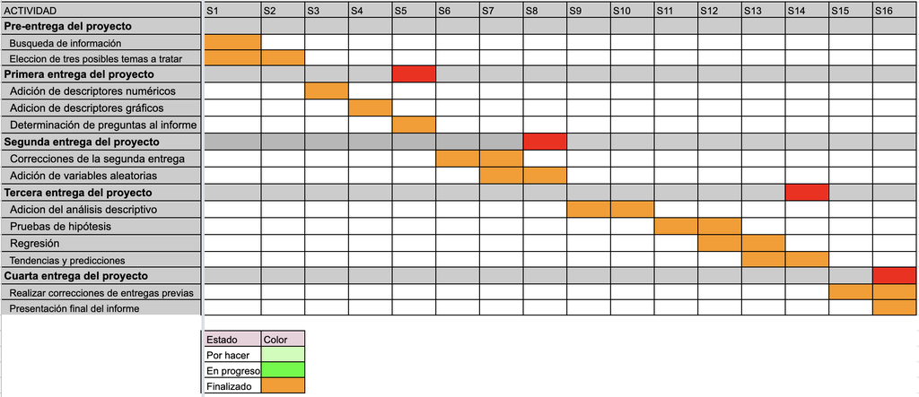

Los detalles de esta organización se encuentran en este link: https://docs.google.com/spreadsheets/d/1RXhSDMx1nmBzVHUCL0tfNYMDOmJ0J0envJsofJFc3n4/edit?usp=sharing

8. BIBLIOGRAFÍA

INEI. Nutrición de los niños. Recuperado de https://proyectos.inei.gob.pe/endes/endes2007/11.%20Lactancia%20y%20Nutrición%20de%20Niños/11.6%20Nutrición%20de%20los%20Niños.html

Instituto Nacional de Salud. Sistema de información del Estado Nutricional de niños y gestantes Perú - INS/CENAN (Instituto Nacional de Salud - Centro Nacional de Alimentación y Nutrición). Recuperado de https://www.datosabiertos.gob.pe/dataset/sistema-de-informaci%C3%B3n-del-estado-nutricional-de-ni%C3%B1os-y-gestantes-per%C3%BA-inscenan-instituto

Ministerio de Salud. La anemia en niños, adolescentes y mujeres gestantes. Recuperado de [<http://bvs.minsa.gob.pe/local/MINSA/4190.pdf>](http://bvs.minsa.gob.pe/local/MINSA/4190.pdf)

Ministerio de Economía y Finanzas. Análisis Territorial: Apurímac. Recuperado de https://www.mef.gob.pe/contenidos/inv_publica/docs/boletines/boletines_pi/boletin5/BIP05_Analisis_Territorial.pdf

Scielo. Propuesta de factor de corrección a las mediciones de hemoglobina por pisos altitudinales en menores de 6 a 59 meses de edad, en el Perú. Recuperado de http://www.scielo.org.pe/scielo.php?script=sci_arttext&pid=S1025-55832017000300005